# EVB par pays

JcB

10/07/2014

# Suivi de l’épidémie de fièvre EBOLA en 2014

source: [promed mail](http://www.promedmail.org) et [OMS](http://who.int/csr/don/2014_07_15_ebola/en/)

[OMS en français](http://who.int/csr/don/archive/disease/ebola/fr/)

[OMS en anglais](http://who.int/csr/don/archive/disease/ebola/en/)

[CDC](http://www.cdc.gov/vhf/ebola/)

[healthmap](http://www.healthmap.org/fr/)

[R Bloggers](http://www.r-bloggers.com/1-2-millions-deaths-by-ebola-projected-within-six-months/) et le [tableau](https://docs.google.com/spreadsheets/d/1GaQg5MgnwxlT_J447N3em8L8obNfwOMfAUEXD6oc4ck/edit#gid=0) associé.

Le 7/8/2014 les donnée sont saisies dans un document partagé sur drive (Ebola). Le fichier *EBOLA 2014 - Pays.csv* remplace le fichier *EVB*pays.csv_. Idem pour newcases.csv. Dans le document RPU_xml on trouvera une méthode pour importer le tableau de l’OMS via R.

Les données sont colligées dans **EVB_PromedMail.ods** puis réenregistrées au format .csv dans **EVB_pays.csv**.

[output not shown]

```
 [1] "EVB_Promed"    "Date"          "Pays"          "Localisation"
 [5] "Total"         "Confirmed"     "Probable"      "Suspected"
 [9] "Death"         "DCD_Confirmed" "DCD_Probable"  "DCD_suspected"
[13] "HCW_case"      "HCW_dcd"
```

```
'data.frame':   203 obs. of  14 variables:
 $ EVB_Promed   : int  NA NA NA NA NA NA 72 72 72 77 ...
 $ Date         : Date, format: "2014-03-24" "2014-03-25" ...
 $ Pays         : Factor w/ 9 levels "Congo","Guinea",..: 2 2 2 3 2 3 2 7 3 2 ...
 $ Localisation : logi  NA NA NA NA NA NA ...
 $ Total        : int  86 90 112 2 122 8 390 136 41 413 ...
 $ Confirmed    : int  NA NA NA NA 24 2 258 103 24 293 ...
 $ Probable     : int  NA NA NA NA 78 NA 88 19 9 88 ...
 $ Suspected    : int  NA NA NA NA 22 NA 44 14 8 32 ...
 $ Death        : int  59 60 70 2 80 2 267 58 25 303 ...
 $ DCD_Confirmed: int  NA NA NA NA 13 1 NA NA NA 193 ...
 $ DCD_Probable : int  NA NA NA NA 67 1 NA NA NA 82 ...
 $ DCD_suspected: int  NA NA NA NA 0 0 NA NA NA 28 ...
 $ HCW_case     : int  NA NA NA NA NA NA NA NA NA NA ...
 $ HCW_dcd      : int  NA NA NA NA NA NA NA NA NA NA ...
```

## Légendes

- HCW_case: personnel de santé contaminés
- HCW_dcd : personnel de santé DCD d’ebola

## Sommes par pays

- **dcd** nombre total de décès
- **cas** nombre total de cas
- **cfr** mortalité globale (en %)
- **cas.g** total des cas en Guinée
- **dcd.g** total des décès en Guinée
- **cfr.g** mortalité en Guinée
- **cas.sl** nombre total de cas en Sierra Leone
- **dcd.sl** total des décès en Sierra L
- __ cfr.sl__mortalité en SL
- **cas.lb** nombre total de cas au Libéria
- **dcd.lb** total des décès au Libéria
- **cfr.lb**mortalité au Libéria
- **dcd.ng** total des décès au Nigéria
- **cas.ng** total des cas au Nigéria
- **cfr.ng** mortalité au Nigéria

NB: les cas représentent la somme des cas suspects, probables et confirmés.

```
## [1] 14098
```

```
## [1] 5160
```

[output not shown]

```
##       Guinea      Liberia         Mali      Nigéria      Senegal
##         1878         6822            4           21            3
## Sierra Leone        Spain          USA
##         5368            4            4
```

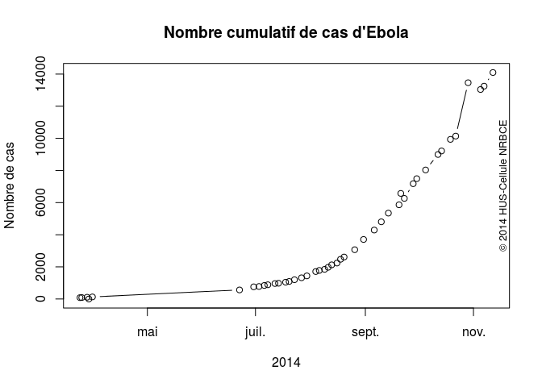

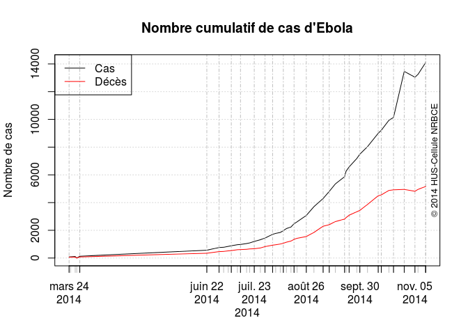

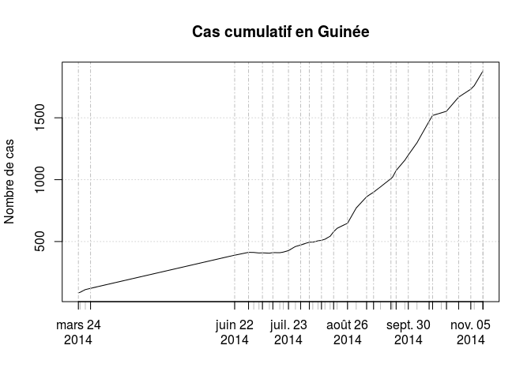

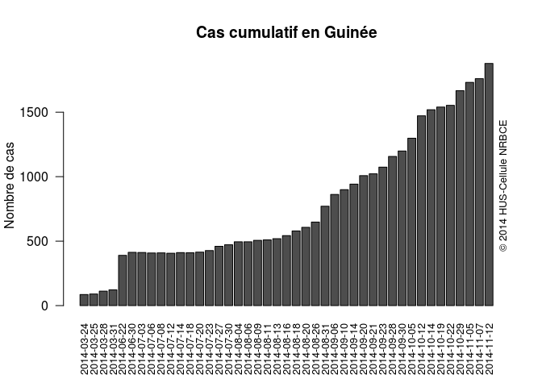

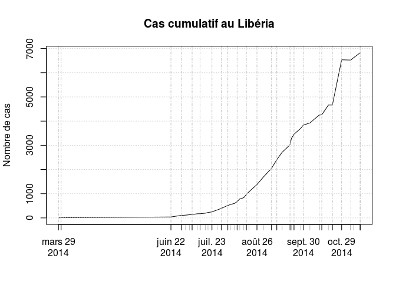

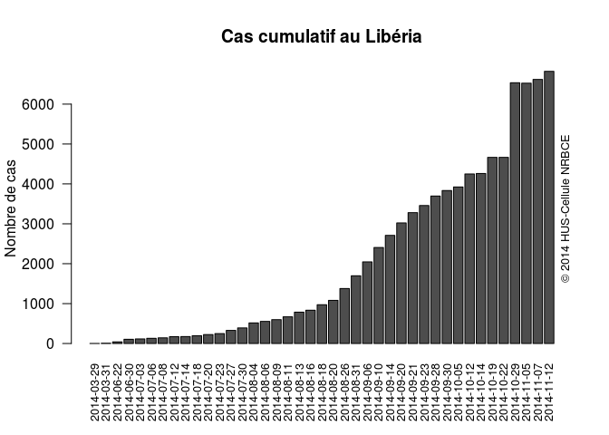

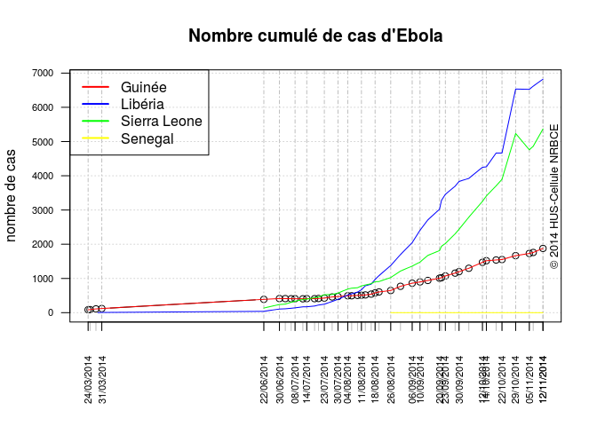

```
## 2014-03-24 2014-03-25 2014-03-28 2014-03-29 2014-03-31 2014-06-22
##         86         90        112          2        130        567
## 2014-06-30 2014-07-03 2014-07-06 2014-07-08 2014-07-12 2014-07-14
##        759        779        844        888        964        982
## 2014-07-18 2014-07-20 2014-07-23 2014-07-27 2014-07-30 2014-08-04
##       1048       1093       1201       1323       1440       1711
## 2014-08-06 2014-08-09 2014-08-11 2014-08-13 2014-08-16 2014-08-18
##       1779       1848       1975       2127       2240       2473
## 2014-08-20 2014-08-26 2014-08-31 2014-09-06 2014-09-10 2014-09-14
##       2615       3070       3707       4293       4806       5347
## 2014-09-20 2014-09-21 2014-09-23 2014-09-28 2014-09-30 2014-10-05
##       5864       6263       6574       7179       7492       8034
## 2014-10-12 2014-10-14 2014-10-19 2014-10-22 2014-10-29 2014-11-05
##       8997       9216       9936      10141      13464      13042
## 2014-11-07 2014-11-12
##      13249      14098
```

```
## 2014-03-24 2014-03-25 2014-03-28 2014-03-29 2014-03-31 2014-06-22
##         59         60         70          2         82        350
## 2014-06-30 2014-07-03 2014-07-06 2014-07-08 2014-07-12 2014-07-14
##        467        481        518        539        603        613
## 2014-07-18 2014-07-20 2014-07-23 2014-07-27 2014-07-30 2014-08-04
##        632        660        672        729        826        932
## 2014-08-06 2014-08-09 2014-08-11 2014-08-13 2014-08-16 2014-08-18
##        961       1013       1069       1145       1229       1350
## 2014-08-20 2014-08-26 2014-08-31 2014-09-06 2014-09-10 2014-09-14
##       1427       1552       1848       2296       2408       2630
## 2014-09-20 2014-09-21 2014-09-23 2014-09-28 2014-09-30 2014-10-05
##       2811       2917       3091       3338       3439       3865
## 2014-10-12 2014-10-14 2014-10-19 2014-10-22 2014-10-29 2014-11-05
##       4493       4555       4877       4922       4951       4818
## 2014-11-07 2014-11-12
##       4952       5160
```

Dernier bilan: 2014-11-12  
Nombre cumulé de cas: 14098  
Nombre cumulé de décès: 5160  
Mortalité globale: 36.6 %  
- mortalité en Guinée: 60.81 %  
- mortalité au Libéria: 41.57 %  
- mortalité en Sierra Leone: 21.78 %

# New Cases et Courbe épidémique

Depuis le 26/8, l’OMS n’indique plus le nombre de nouveaux cas. Il faut donc les calculer par soustraction des 2 derniers bilans.

Exemple avec la Guinée:

```r
source("ebola_functions.R")

a <- tapply(d$Total[d$Pays=="Guinea"], d$Date[d$Pays=="Guinea"], sum)
n <- length(a)
b <- a[n] - a[n-1]
```

Pour la Guinée:  
- dernier bilan: 2014-11-12  
- nombre total de nouveau cas: 118

Il faut répéter l’opération pour les autres comptes (Confirmed, Probable, suspected) et les autres pays => function

Il est possible de simplifier le calcul en utilisant l’instruction **diff** qui calcule les différences successives.

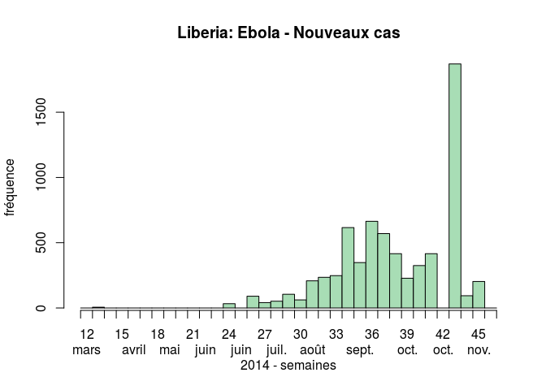

```r
state <- "Liberia"
a <- tapply(d$Total[d$Pays == state], d$Date[d$Pays == state], sum)
a1 <- names(a)
a2 <- as.numeric(a)
a3 <- c(0, diff(a)) # premier élément = 0 car 1ère différence nulle
a3[a3 < 0] <- 0 # si différence négative on ramène à 0
b <- data.frame(a1,a2,a3)
names(b) <- c("date","cumul","delta")

# On crée autant d'enregistrements qu'il y a de cas
x.date <- rep(b$date, b$delta)
ebola <- epicurve.weeks(x.date, sunday = FALSE, axisnames = FALSE, col="#A8DDB5")
axis(1, at = ebola$xvals, labels = ebola$cweek, tick = FALSE, line = 0)
axis(1, at = ebola$xvals, labels = ebola$cmonth, tick = FALSE, line = 1)
title(main= paste0(state,": Ebola - Nouveaux cas"), ylab = "fréquence", xlab = "2014 - semaines")
```

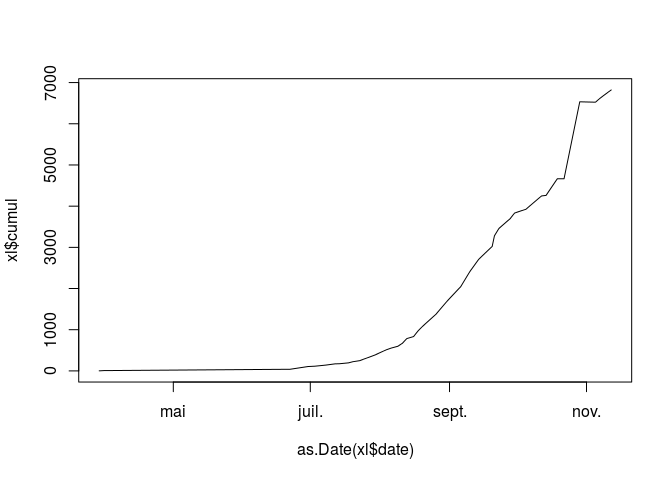

```r
# voir la routine new.case()
xl <- new.case(d, state)
plot(as.Date(xl$date), xl$cumul, type="l")
```

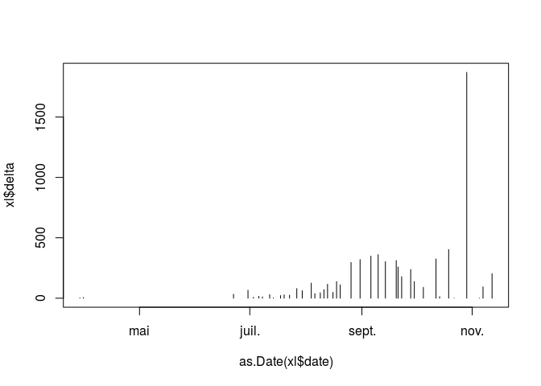

```r
plot(as.Date(xl$date), xl$delta, type="h")
```

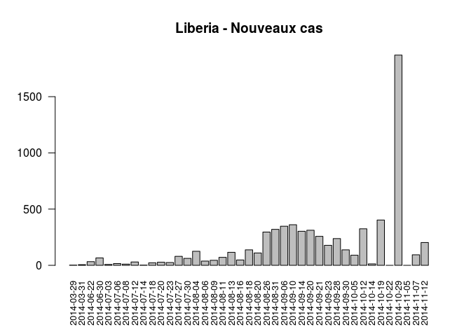

```r
barplot(xl$delta, names.arg=xl$date, las=2, cex.names = 0.8, main = paste0(state," - Nouveaux cas"))
```

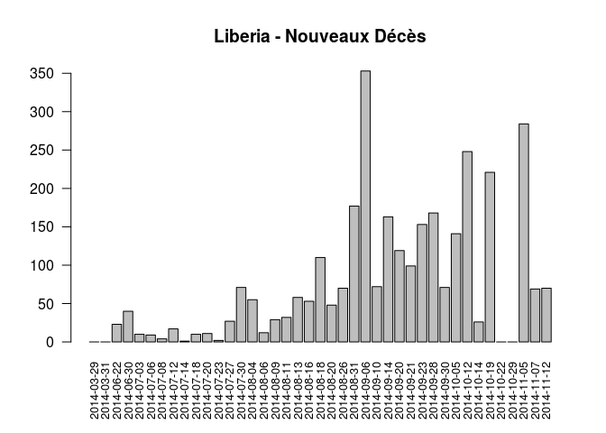

```r
# idem avec new.death()
xd <- new.death(d, state)
barplot(xd$delta, names.arg=xd$date, las=2, cex.names = 0.8, main = paste0(state," - Nouveaux Décès"))
```

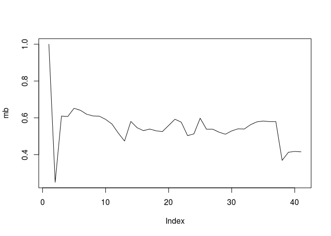

```r
# taux de mortalité brut et à 15 jours
mb <- xd$cumul/xl$cumul
plot(mb, type="l")
```

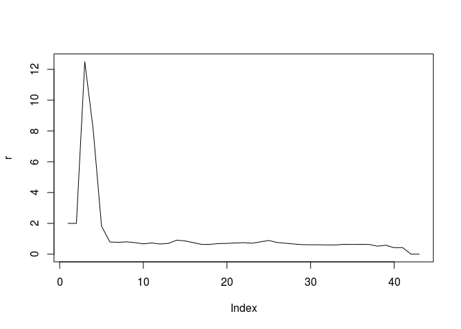

```r
xll <- c(1,1,xl$cumul) # impose un décalage de 15 jours
xdd <- c(xd$cumul,1,1)
r <- round(xdd/xll, 2)
plot(r, type="l")
```

## Nouveaux cas: automatisation avec ebola_function

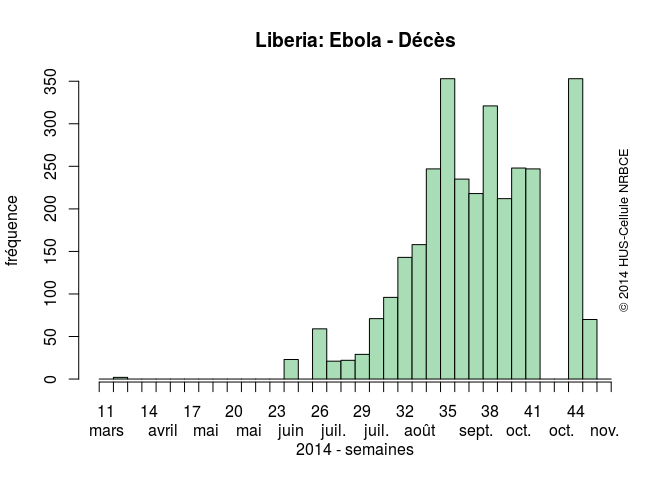

```r
state <- "Liberia"
nd <-new.case(d, state, "Death") # nouveau décès au Libéria
ebola.curve(nd, state, title="Décès")
```

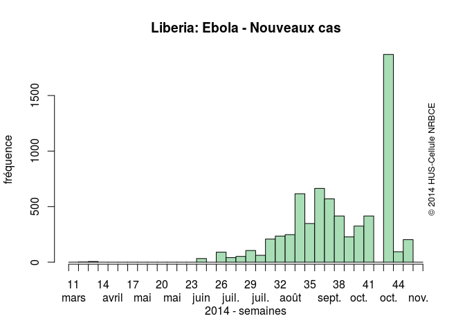

[output not shown]

[figure not shown]

[figure not shown]

```r
nc <-new.case(d, state, "Total")
ebola.curve(nc, state, title="Nouveaux cas")
```

## Nouveaux cas par pays

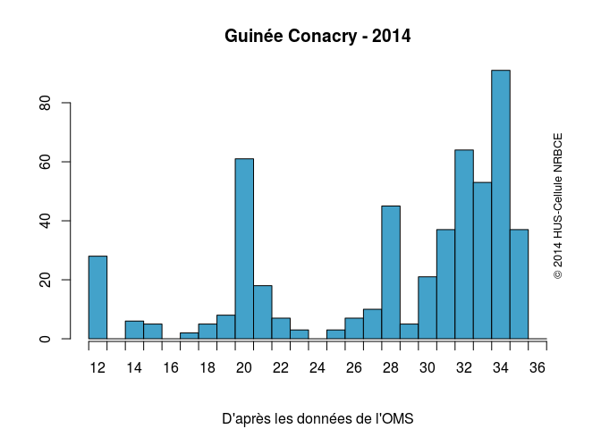

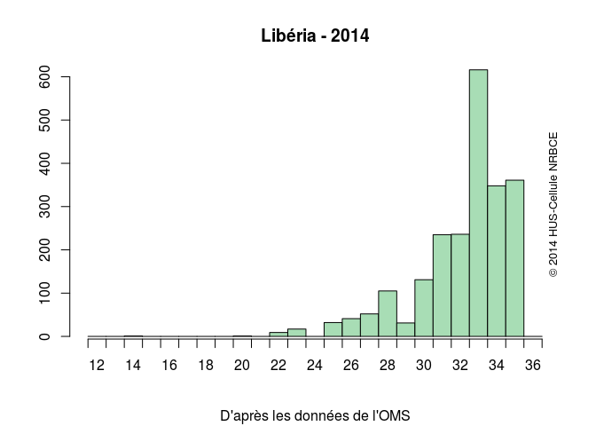

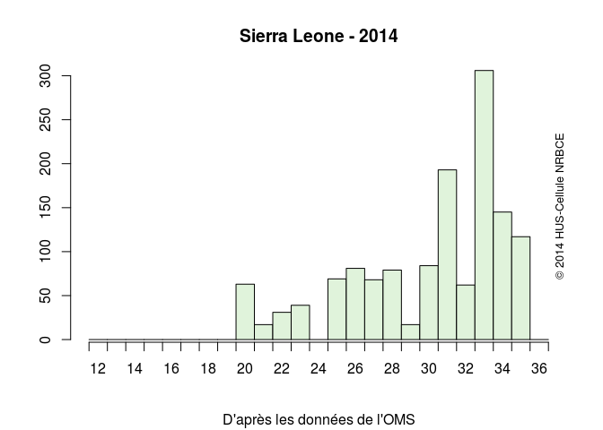

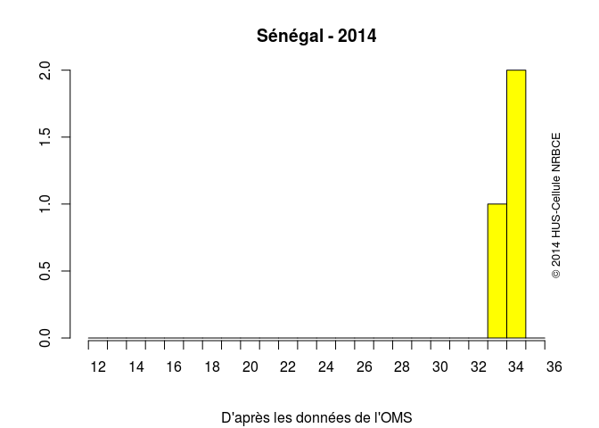

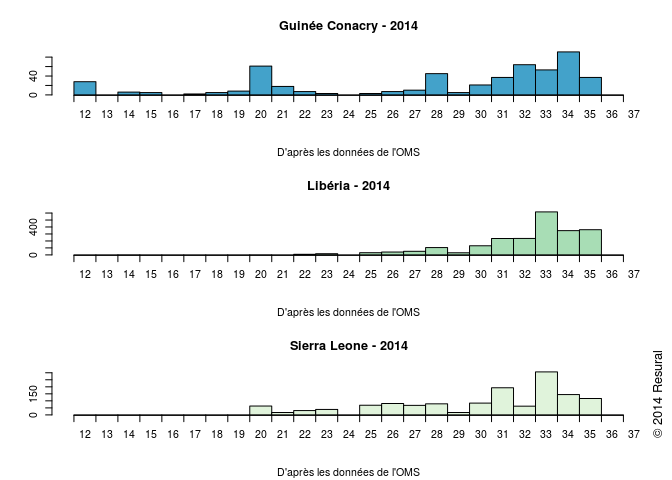

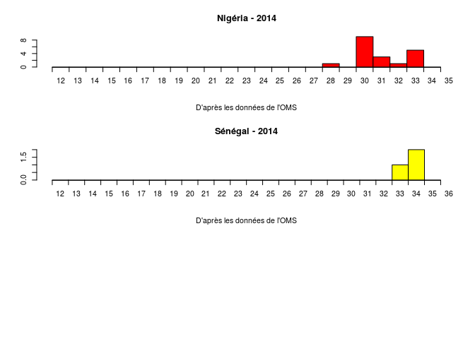

ToDo: cartographie